10 - Midterm exam 第四組  
10773020 李庭溱  
11773028 葛俊余  
11773035 簡柏宇  
11773040 余俊宏  
2022-11-11

```r
library(dplyr)
library(data.table)
library(stringr)
library(scales)
library(ggplot2)
library(ggthemes)
library(ggrepel)
library(colorspace)
library(kableExtra)
showtext::showtext.auto(enable = TRUE)
showtext::showtext_opts(dpi = 300)
```

# 1 某基金會針對行政院推動的三倍券進行民調

## 1.1 關於這張圖的呈現請問您覺得是否合適

- 不適合，看不太出來人群中意象的佔比，折線圖比較適合表達趨勢

## 1.2 您會如何呈現此結果

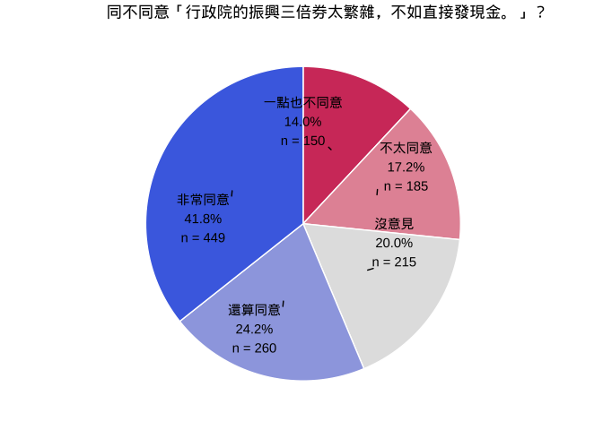

```r
data_1 <- data.frame(
  fill = c(1:5, NA),
  x = c(.14, .172, .2, .242, .418, 0.04)
) %>%
  mutate(
    fill = fill %>%
      factor(
        .,
        1:5,
        c("一點也不同意", "不太同意", "沒意見", "還算同意", "非常同意")
      ) %>% forcats::fct_rev(),
    label = paste(fill, "\n", x %>% percent(), "\nn = ", (x * 1074) %>% round(), sep = "")
  )

data_1 %>%
  filter(!is.na(fill)) %>%
  ggplot(aes(x = x, y = "", fill = fill, label = label)) +
  geom_col(position = position_stack(), width = .4, color = "white") +
  geom_text_repel(position = position_stack(vjust = .5), min.segment.length = 0) +
  labs(title = "同不同意「行政院的振興三倍券太繁雜，不如直接發現金。」？") +
  coord_polar() +
  scale_fill_discrete_diverging("Blue Red2", rev = F) +
  theme_light() +
  theme(
    legend.position = "none",
    legend.title = element_blank(),
    axis.title = element_blank(),
    axis.ticks = element_blank(),
    axis.text = element_blank(),
    panel.background = element_blank(),
    panel.border = element_blank(),
    panel.grid = element_blank()
  )
```

# 2 假設在某族群有接受流感疫苗接種的比例佔七成，打過疫苗的人後來得流感的機率為 0.1，沒打過流感疫苗的人得流感的機率為 0.4

## 2.1 請製作列聯表

```r
data_2 <- data.frame(
  group = c("是", "否"),
  prop = c(.7, 1 - .7),
  dz = c(.1, .4)
) %>%
  mutate(non_dz = 1 - dz) %>%
  mutate_at(.vars = c("dz", "non_dz"), ~ prop * .)

rbind(
  data_2,
  data_2 %>%
    mutate(group = "總計") %>%
    group_by(group) %>%
    summarise_all(sum)
) %>%
  select(1, 3, 4, 2) %>%
  mutate_if(is.numeric, ~ percent(., 1)) %>%
  kable(
    col.names = c("疫苗施打", "是", "否", "總計"),
    align = "crrr"
  ) %>%
  kable_styling(full_width = F) %>%
  add_header_above(c(" " = 1, "得流感" = 3))
```

| 疫苗施打 | 得流感 是 | 得流感 否 | 得流感 總計 |
| --- | --- | --- | --- |
| 是 | 7% | 63% | 70% |
| 否 | 12% | 18% | 30% |
| 總計 | 19% | 81% | 100% |

## 2.2 從此族群隨機挑選一群流感病人，請問曾接種疫苗的比例是多少

$P(V_{true}) = 0.7$

$P(V_{false}) = 0.3$

$P(I_{true} | V_{true}) = 0.1$

$P(I_{true} | V_{false}) = 0.4$

$P(I_{true}) = P(I_{true} | V_{true}) \times P(V_{true}) + P(I_{true} | V_{false}) \times P(V_{false}) = 0.7 \times 0.1 + 0.3 \times 0.4 = 0.19$

$P(V_{true}|I_{true}) = \frac{P(I_{true}) \cap P(V_{true})}{P(I_{true})} = \frac{P(I_{true}|V_{true}) \times P(V_{true})}{P(I_{true})} = \frac{0.1\times0.7}{0.19} = 0.368$

## 2.3 請問接種流感疫苗與罹患流感是否相關

故，兩族群染疫機率的

- rate difference：$0.1 - 0.4 = -0.3$
- rate ratio：$0.1 / 0.4 = 0.25$

因 rate difference < 0、rate ratio < 1，故猜測施打疫苗對染疫有保護效果（負相關）

# 3 某校學生會向學校提出某個建議，並針對大學部學生、研究所學生、及教職員進行調查

## 3.1 同意改變的大學生之機率

```r
data_3 <- data.frame(
  v = c("反對改變", "贊成改變"),
  s_b = c(73, 27),
  s_m = c(27, 23),
  t = c(20, 30)
)
data_3 %>%
  kable(col.names = c("意向", "大學生", "研究生", "教師")) %>%
  kable_styling(full_width = F)
```

| 意向 | 大學生 | 研究生 | 教師 |
| --- | --- | --- | --- |
| 反對改變 | 73 | 27 | 20 |
| 贊成改變 | 27 | 23 | 30 |

$P(贊成改變|大學生) = 27 / (27 + 73) = 27 / 100 = 0.27$

## 3.2 校園中隨機找一位研究生，他/她贊成的機率

$P(贊成改變|研究生) = 23 / (23 + 27) = 23 / 50 = 0.46$

## 3.3 贊成改變或大學生的機率

$P(贊成改變) \cup P(大學生) = \frac{(73 + 27) + (23 + 30)}{(73 + 27 + 20 + 27 + 23 + 30)} = \frac{153}{200} = 0.765$

## 3.4 找任何一位學生，其反對學生會提議的機率

$P(反對改變|學生) = \frac{73+27}{27+23+73+27} = \frac{100}{150} = 0.667$

## 3.5 請列出各身分別的反對率

大學生: $\frac{73}{73+27} = 0.73$、研究生: $\frac{27}{27+23} = 0.54$、教師: $\frac{20}{20+30} = 0.4$

## 3.6 請問在校身分與是否贊同學生會提議是否相關

若無相關則各族群反對率應一致；但大學生與研究生反對率高、教師反對率低，故猜測有相關

# 4 請參考期中報告.xlsx 檔案中 data 工作表的檔案

## 4.1 請利用適當的描述統計指標，說明這個欄位

```r
data_4 <- data.frame(time = c(
  2.1, 14.7, 4.1, 14.1, 1.6,
  4.4, 9.6, 18.4, 1, 3.5,
  2.7, 16.7, 0.2, 2.4, 11.4,
  32.3, 7.4, 6.1, 2.4, 18,
  9.9, 8.2, 13.5, 18, 26.7,
  9, 19.2, 7.4, 8.7, 3.7,
  2, 6.9, 0.2, 24, 12.6,
  6.6, 4.3, 8.3, 1.4, 23.1,
  3.9, 3.3, 0.3, 8.2, 5.6,
  1.6, 1.2, 1.3, 5.8, 0.4
))

data_4 %>%
  summarise(
    sample = n(),
    mean = time %>% mean(),
    sd = time %>% mean(),
    log_mean = time %>% log() %>% mean(),
    log_sd = time %>% log() %>% sd(),
    q1 = time %>% quantile(., probs = .25),
    q2 = time %>% quantile(., probs = .50),
    q3 = time %>% quantile(., probs = .75)
  ) %>%
  ungroup() %>%
  mutate_all(~ comma(., 0.01)) %>%
  kable(
    align = "r",
    col.names = c(
      "樣本數", "平均值", "標準差",
      "Log 平均值", "Log 標準差",
      "25th 分位", "50th 百分位", "75th 百分位"
    )
  ) %>%
  kable_styling(full_width = F)
```

[output not shown]

## 4.2 此變項呈現什麼樣的分布形狀

右偏，分佈右側的尾部比左側的長，絕大多數的數值與中位數位於平均值的左側

## 4.3 請利用 Empirical rule 推測資料的最大值跟最小值分別是多少

- log 平均值: $1.58$
- log 標準差: $1.25$
- 兩個標準差是: $2 \times 1.25 = 2.5$
- 所以 95% 的數據應該落在: $[exp^{1.58 - 2.5}, exp^{1.58 + 2.5}] = [0.399 - 59.15]$
- 故猜測最小值: 0.399、最大值: 59.15

## 4.4 請問此資料是否適用 Empirical rule

- 這是有偏度的數據，而且時間應 >0，故直接用平均值、標準差算不行，取 log 後的則可以

## 4.5 請根據此結果繪製直方圖與盒形圖

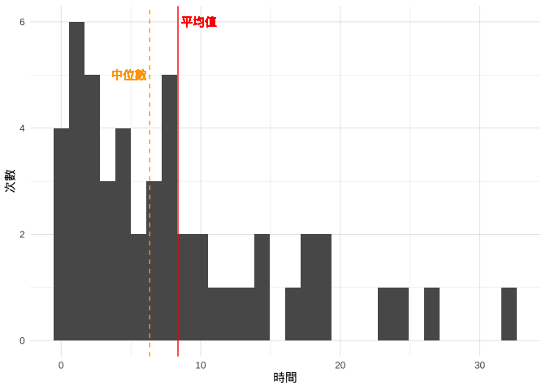

```r
data_4 %>%
  ggplot(aes(time)) +
  geom_histogram() +
  geom_vline(xintercept = c(8.37), linetype = 1, color = "red") +
  geom_vline(xintercept = c(6.35), linetype = 2, color = "orange") +
  geom_text(aes(x = 8.37 + 1.5, y = 6, label = "平均值"), color = "red") +
  geom_text(aes(x = 6.35 - 1.5, y = 5, label = "中位數"), color = "orange") +
  labs(x = "時間", y = "次數") +
  theme_light() +
  theme(
    legend.position = "none",
    legend.title = element_blank(),
    axis.ticks = element_blank(),
    panel.background = element_blank(),
    panel.border = element_blank()
  )
```

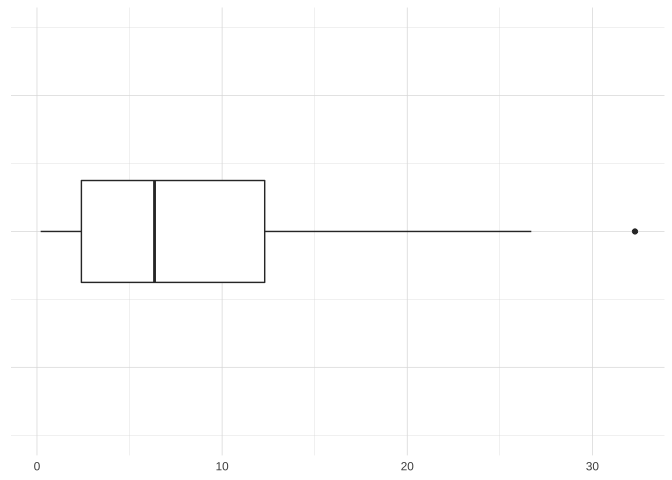

```r
data_4 %>%
  ggplot(aes(time)) +
  geom_boxplot() +
  scale_y_continuous(limits = c(-1.5, 1.5)) +
  theme_light() +
  theme(
    legend.position = "none",
    legend.title = element_blank(),
    axis.title = element_blank(),
    axis.ticks = element_blank(),
    axis.text.y = element_blank(),
    panel.background = element_blank(),
    panel.border = element_blank()
  )
```

# 5 Mini Project

請參考”期中報告.xlsx”檔案中” ATM Data”工作表

這是某家銀行在三個地方ATM的交易狀況，這三個地方在同一個行政區

```r
data_5 <- "20221111_midterm_exam_atm_data.csv" %>% fread()
data_5 %>%
  group_by(Location, Type) %>%
  summarise(
    sample = n(),
    sum = Amount %>% sum(),
    mean = Amount %>% mean(),
    q1 = Amount %>% quantile(., probs = .25),
    q2 = Amount %>% quantile(., probs = .50),
    q3 = Amount %>% quantile(., probs = .75)
  ) %>%
  mutate_if(is.numeric, ~ comma(., 1)) %>%
  kable(
    col.names = c(
      "位置", "交易", "次數", "總計",
      "平均值", "25 th", "50 th", "75 th"
    ),
    align = "ccrrrrrr"
  ) %>%
  collapse_rows(c(1, 2)) %>%
  add_header_above(c(" " = 3, "金額" = 5)) %>%
  kable_styling(full_width = T, c("hover", "condensed", "striped"))
```

| 位置 | 交易 | 次數 | 金額 總計 | 金額 平均值 | 金額 25 th | 金額 50 th | 金額 75 th |
| --- | --- | --- | --- | --- | --- | --- | --- |
| CampusA | Transfer | 13 | 560,000 | 43,077 | 3,000 | 21,000 | 90,000 |
|  | Withdrawal | 645 | 1,065,000 | 1,651 | 1,000 | 1,000 | 2,000 |
| CampusB | Deposit | 1,459 | 11,412,000 | 7,822 | 2,000 | 4,000 | 9,000 |
|  | Transfer | 196 | 2,364,000 | 12,061 | 2,000 | 5,000 | 15,000 |
|  | Withdrawal | 5,630 | 8,853,000 | 1,572 | 1,000 | 1,000 | 2,000 |
| DriveUp | Deposit | 2,203 | 46,289,000 | 21,012 | 4,000 | 9,000 | 21,000 |
|  | Transfer | 213 | 6,093,000 | 28,606 | 3,000 | 9,000 | 27,000 |
|  | Withdrawal | 4,554 | 13,274,000 | 2,915 | 1,000 | 2,000 | 3,000 |

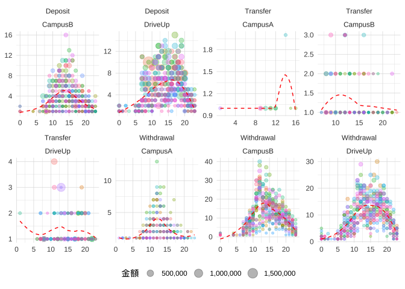

```r
data_5 %>%
  group_by(Type, Location, Date, Hour) %>%
  summarise(
    n = n(),
    sum = Amount %>% sum()
  ) %>%
  ggplot(aes(x = Hour, y = n, color = Date %>% factor(), size = sum)) +
  geom_point(alpha = .3) +
  geom_smooth(se = F, size = .5, color = "red", linetype = 2) +
  labs(x = "Hour", "Times") +
  facet_wrap(Type ~ Location, ncol = 4, scales = "free") +
  scale_size(label = comma_format(1)) +
  guides(color = F) +
  labs(color = "時間", size = "金額", x = "時間", y = "次數") +
  theme_light() +
  theme(
    legend.position = "bottom",
    strip.background = element_blank(),
    strip.text = element_text(color = "gray20"),
    axis.title = element_blank(),
    axis.ticks = element_blank(),
    panel.background = element_blank(),
    panel.border = element_blank()
  )
```

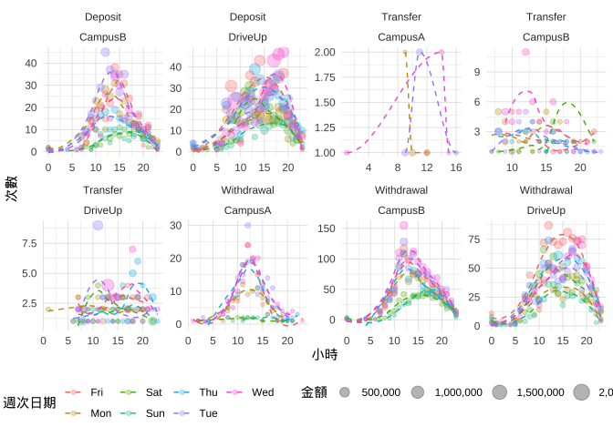

```r
data_5 %>%
  group_by(Type, Location, Weekday, Hour) %>%
  summarise(
    n = n(),
    sum = Amount %>% sum()
  ) %>%
  ggplot(aes(x = Hour, y = n, color = Weekday %>% factor(), size = sum)) +
  geom_point(alpha = .3) +
  geom_smooth(se = F, size = .5, linetype = 2) +
  facet_wrap(Type ~ Location, ncol = 4, scales = "free") +
  scale_size(label = comma_format(1)) +
  labs(color = "週次日期", size = "金額", x = "小時", y = "次數") +
  theme_light() +
  theme(
    legend.position = "bottom",
    strip.background = element_blank(),
    strip.text = element_text(color = "gray20"),
    axis.ticks = element_blank(),
    panel.background = element_blank(),
    panel.border = element_blank()
  )
```

[figure not shown]

```r
data_5 %>%
  mutate(
    cashflow = ifelse(Type == "Deposit",
      Amount,
      ifelse(Type == "Withdrawal", -Amount, 0)
    ),
    datehour = ("2022-01-01" %>% as.Date() + Date - 1) %>%
      format(., paste("%Y-%m-%d ",
        sprintf("%02d", Hour),
        ":00:00",
        sep = ""
      )) %>% as.POSIXct()
  ) %>%
  group_by(Location, datehour, Weekday) %>%
  mutate(cashflow = cashflow %>% sum()) %>%
  ungroup() %>%
  arrange(Location, datehour) %>%
  group_by(Location) %>%
  mutate(cashflow = cashflow %>% cumsum()) %>%
  ggplot(aes(datehour, cashflow)) +
  geom_line() +
  facet_wrap(~Location, scale = "free_y", ncol = 1) +
  scale_y_continuous(labels = comma_format(1)) +
  labs(x = "日期時間", y = "存提差") +
  theme_light() +
  theme(
    legend.position = "none",
    legend.title = element_blank(),
    strip.background = element_blank(),
    strip.text = element_text(color = "gray20"),
    axis.ticks = element_blank(),
    panel.background = element_blank(),
    panel.border = element_blank()
  )
```

## 5.1 現在該銀行想要擬定一份現金運送的計畫，該計畫需要說明運送時間與頻率、應準備的金額等，除此之外，您亦可視情況補充計畫內容

- 條件一：提款機可以放 5 至 8 百萬，也就是存提差接近 5 百萬後會滿、接近 -5 百萬會空，所以應在存提差絕對值 < 500 內運送一次
- 條件二：運送時間即為一班上班時間週一至週五 09 - 15 間
- 條件三：應避開存轉提尖峰時段
- 條件四：運鈔車沒有現金上限

基於上述，可以利用歷史個站點的存提差模擬 MC 出更多數據，並配合 LP 求最佳

## 5.2 部門主管在詢問目前三個ATM是否足夠，是否有必要設新的ATM，如果有必要，地點選在哪裡比較好

存提差以及存轉提次數太多可能是負擔，就存提差來說是 DriveUp 最大，Campus B 次數最多；但 Campus B 存轉提次數尖離峰差大，DriveUp 小，表示 DriveUp 可能比較有 throuput 問題，故選 DriveUp 附近設置新 ATM

## 5.3 假設 Campus A 的ATM提款金額呈現常態分佈，請問提款金額低於5000元的機率是多少，另外請計算資料中提款金額低於5000元的百分比，並比較兩個結果是否相同，如果不相同，請說明可能是什麼原因

不同，假設為常態分佈提款金額可能 <0 不符合邏輯，也不會發生

```r
data_5 %>%
  filter(
    Type == "Withdrawal",
    Location == "CampusA"
  ) %>%
  summarise(
    mean = Amount %>% mean(),
    sd = Amount %>% mean(),
    p_less_than_5k = pnorm(5000, mean, sd),
    less_than_5k = sum(Amount < 5000) / n()
  ) %>%
  mutate_at(.vars = c("mean", "sd"), ~ comma(., 1)) %>%
  mutate_at(.vars = c("p_less_than_5k", "less_than_5k"), ~ percent(., .01)) %>%
  kable(col.names = c(
    "平均值", "標準差",
    "推估<5K 機率", "實際 <5K 比例"
  ), align = "r") %>%
  kable_styling(full_width = F)
```

[output not shown]

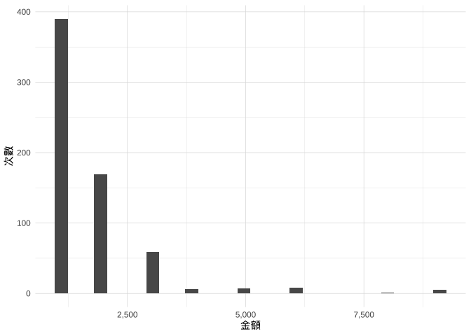

```r
data_5 %>%
  filter(
    Type == "Withdrawal",
    Location == "CampusA"
  ) %>%
  ggplot(aes(Amount)) +
  geom_histogram() +
  labs(x = "金額", y = "次數") +
  scale_x_continuous(labels = comma_format(1)) +
  theme_fivethirtyeight(base_family = "wqy-microhei") +
  theme_light() +
  theme(
    legend.position = "none",
    legend.title = element_blank(),
    strip.background = element_blank(),
    strip.text = element_text(color = "gray20"),
    axis.ticks = element_blank(),
    panel.background = element_blank(),
    panel.border = element_blank()
  )
```